# Business Forecasting Week 2 HW

Juan Romo

### Load Packages

```r
library(ggplot2)
library(readxl)
library(gridExtra)
library(scales)
```

### Import Data from Excel

```r
Typical_Employee_Survey_Data <- read_excel("C:/Users/jprom/Desktop/Class Notes/Class Fall 2023/Business Forecasting/Week 2/HW/Typical_Employee_Survey_Data.xlsx",
    col_names = FALSE)
#View(Typical_Employee_Survey_Data)
```

### Duplicate Data

```r
survey_data <- Typical_Employee_Survey_Data

head(survey_data)
```

| ...1 | ...2 | ...3 | ...4 | ...5 | ...6 | ...7 | ...8 | ...9 | ...10 | ...11 |
| --- | --- | --- | --- | --- | --- | --- | --- | --- | --- | --- |
| 35 | 1 | 2 | 4 | 3.0 | 1 | 2 | 1 | 2 | 5 | 2 |
| 33 | 1 | 2 | 3 | 9.0 | 5 | 2 | 1 | 2 | 2 | 1 |
| 23 | 1 | 1 | 1 | 1.5 | 1 | 2 | 2 | 1 | 5 | 2 |
| 60 | 1 | 1 | 1 | 20.0 | 3 | 2 | 2 | 1 | 1 | 1 |
| 35 | 1 | 2 | 1 | 3.0 | 3 | 2 | 1 | 2 | 4 | 2 |
| 34 | 2 | 2 | 1 | 6.0 | 1 | 2 | 2 | 2 | 4 | 4 |

```r
NA
```

### Convert to Dataframe

```r
survey_data <- data.frame(survey_data)

str(survey_data)
```

```
'data.frame':   122 obs. of  11 variables:
 $ ...1 : num  35 33 23 60 35 34 61 59 37 30 ...
 $ ...2 : num  1 1 1 1 1 2 2 1 2 1 ...
 $ ...3 : num  2 2 1 1 2 2 1 2 1 1 ...
 $ ...4 : num  4 3 1 1 1 1 1 5 5 5 ...
 $ ...5 : num  3 9 1.5 20 3 6 0.75 1.5 3 5 ...
 $ ...6 : num  1 5 1 3 3 1 5 2 4 2 ...
 $ ...7 : num  2 2 2 2 2 2 3 1 3 2 ...
 $ ...8 : num  1 1 2 2 1 2 2 2 1 1 ...
 $ ...9 : num  2 2 1 1 2 2 2 2 2 1 ...
 $ ...10: num  5 2 5 1 4 4 4 4 2 2 ...
 $ ...11: num  2 1 2 1 2 4 1 1 3 2 ...
```

```r
summary(survey_data)
```

```
      ...1           ...2            ...3            ...4            ...5             ...6            ...7
 Min.   :20.0   Min.   :1.000   Min.   :1.000   Min.   :1.000   Min.   : 0.080   Min.   :1.000   Min.   :1.000
 1st Qu.:33.0   1st Qu.:1.000   1st Qu.:1.000   1st Qu.:2.000   1st Qu.: 2.000   1st Qu.:2.000   1st Qu.:2.000
 Median :38.0   Median :1.000   Median :1.000   Median :5.000   Median : 5.000   Median :4.000   Median :2.000
 Mean   :39.1   Mean   :1.426   Mean   :1.631   Mean   :3.705   Mean   : 8.224   Mean   :3.287   Mean   :2.279
 3rd Qu.:44.0   3rd Qu.:2.000   3rd Qu.:2.000   3rd Qu.:5.000   3rd Qu.:11.000   3rd Qu.:5.000   3rd Qu.:3.000
 Max.   :64.0   Max.   :2.000   Max.   :4.000   Max.   :5.000   Max.   :52.250   Max.   :5.000   Max.   :4.000
      ...8            ...9           ...10           ...11
 Min.   :1.000   Min.   :1.000   Min.   :1.000   Min.   :1.000
 1st Qu.:1.000   1st Qu.:1.000   1st Qu.:2.000   1st Qu.:1.000
 Median :1.000   Median :2.000   Median :4.000   Median :2.000
 Mean   :1.451   Mean   :1.787   Mean   :3.254   Mean   :1.787
 3rd Qu.:2.000   3rd Qu.:2.000   3rd Qu.:4.000   3rd Qu.:2.000
 Max.   :2.000   Max.   :4.000   Max.   :5.000   Max.   :4.000
```

## Data Cleaning

### Change Column Names

```r
colnames(survey_data) <- c('Age','Gender','Job_Sat','Job_Char','Yrs_Emplyd','Prom_5yr','Make_Decision',
                           'Bud_Decisions','Proud_Org', 'Decline_Incr_Pay','Work_Relation')
head(survey_data)
```

|  | Age | Gender | Job_Sat | Job_Char | Yrs_Emplyd | Prom_5yr | Make_Decision | Bud_Decisions | Proud_Org | Decline_Incr_Pay | Work_Relation |
| --- | --- | --- | --- | --- | --- | --- | --- | --- | --- | --- | --- |
| 1 | 35 | 1 | 2 | 4 | 3.0 | 1 | 2 | 1 | 2 | 5 | 2 |
| 2 | 33 | 1 | 2 | 3 | 9.0 | 5 | 2 | 1 | 2 | 2 | 1 |
| 3 | 23 | 1 | 1 | 1 | 1.5 | 1 | 2 | 2 | 1 | 5 | 2 |
| 4 | 60 | 1 | 1 | 1 | 20.0 | 3 | 2 | 2 | 1 | 1 | 1 |
| 5 | 35 | 1 | 2 | 1 | 3.0 | 3 | 2 | 1 | 2 | 4 | 2 |
| 6 | 34 | 2 | 2 | 1 | 6.0 | 1 | 2 | 2 | 2 | 4 | 4 |

### Check for Missing Values

```r
total_obs <- ncol(survey_data)*nrow(survey_data)

total_obs
```

```
[1] 1342
```

```r
na_count <- sum(is.na(survey_data))

na_count
```

```
[1] 0
```

### Set Appropriate Data Types

```r
# Set Factor Variables

survey_data$Gender <- factor(survey_data$Gender, labels = c("M","F"))
survey_data$Gender[1:20]
```

```
 [1] M M M M M F F M F M F F F M M M F F F M
Levels: M F
```

```r
# Overall Job Satisfaction Ranking

survey_data$Job_Sat <- factor(survey_data$Job_Sat,
                              levels = c(4,3,2,1),
                              labels = c("VDis_Sat","ModDis_Sat","Mod_Sat","V_Sat"),
                              ordered= T)
survey_data$Job_Sat[1:20]
```

```
 [1] Mod_Sat    Mod_Sat    V_Sat      V_Sat      Mod_Sat    Mod_Sat    V_Sat      Mod_Sat    V_Sat      V_Sat      V_Sat
[12] Mod_Sat    Mod_Sat    V_Sat      ModDis_Sat Mod_Sat    Mod_Sat    Mod_Sat    V_Sat      V_Sat
Levels: VDis_Sat < ModDis_Sat < Mod_Sat < V_Sat
```

```r
# Important Job Characteristics

survey_data$Job_Char <- factor(survey_data$Job_Char,
                               labels = c("High_Income", "NoDanger_Fired", "Flex_Hours", "Opps_Advanc", "Enjoy_Work"))
survey_data$Job_Char[1:20]
```

```
 [1] Opps_Advanc Flex_Hours  High_Income High_Income High_Income High_Income High_Income Enjoy_Work  Enjoy_Work  Enjoy_Work
[11] Flex_Hours  Flex_Hours  Enjoy_Work  Opps_Advanc High_Income Opps_Advanc High_Income Enjoy_Work  Opps_Advanc Enjoy_Work
Levels: High_Income NoDanger_Fired Flex_Hours Opps_Advanc Enjoy_Work
```

```r
# Likely to be Promoted in 5 Years

survey_data$Prom_5yr <- factor(survey_data$Prom_5yr,
                              levels = c(5,4,3,2,1),
                              labels = c("V_Unlikely", "Unlikely", "Unsure", "Likely", "V_Likely"),
                              ordered= T)
survey_data$Prom_5yr[1:20]
```

```
 [1] V_Likely   V_Unlikely V_Likely   Unsure     Unsure     V_Likely   V_Unlikely Likely     Unlikely   Likely     Unlikely
[12] Likely     Likely     V_Likely   Unlikely   V_Unlikely Likely     Unlikely   Unsure     V_Unlikely
Levels: V_Unlikely < Unlikely < Unsure < Likely < V_Likely
```

```r
# Take Part in Decision Making

survey_data$Make_Decision <- factor(survey_data$Make_Decision,
                              levels = c(4,3,2,1),
                              labels = c("Never", "SomeTime", "MuchTime", "Always"),
                              ordered= T)
survey_data$Make_Decision[1:20]
```

```
 [1] MuchTime MuchTime MuchTime MuchTime MuchTime MuchTime SomeTime Always   SomeTime MuchTime MuchTime MuchTime SomeTime
[14] MuchTime MuchTime MuchTime SomeTime MuchTime MuchTime SomeTime
Levels: Never < SomeTime < MuchTime < Always
```

```r
# Participate in Budget Decisions

survey_data$Bud_Decisions <- factor(survey_data$Bud_Decisions,
                              levels = c(1,2),
                              labels = c("Yes", "No"))

survey_data$Bud_Decisions[1:20]
```

```
 [1] Yes Yes No  No  Yes No  No  No  Yes Yes Yes Yes No  Yes No  Yes No  No  Yes Yes
Levels: Yes No
```

```r
# Proud to Work For Organization

survey_data$Proud_Org <- factor(survey_data$Proud_Org,
                              levels = c(4,3,2,1),
                              labels = c("Not_Proud", "Indifferent", "Some_Proud", "Proud"),
                              ordered= T)
survey_data$Proud_Org[1:20]
```

```
 [1] Some_Proud Some_Proud Proud      Proud      Some_Proud Some_Proud Some_Proud Some_Proud Some_Proud Proud      Proud
[12] Some_Proud Some_Proud Some_Proud Not_Proud  Some_Proud Some_Proud Some_Proud Proud      Proud
Levels: Not_Proud < Indifferent < Some_Proud < Proud
```

```r
# Turn down another job for more pay to stay with org.

survey_data$Decline_Incr_Pay <- factor(survey_data$Decline_Incr_Pay,
                              levels = c(5,4,3,2,1),
                              labels = c("V_Unlikely", "Unlikely", "Unsure", "Likely", "V_Likely"),
                              ordered= T)

survey_data$Decline_Incr_Pay[1:20]
```

```
 [1] V_Unlikely Likely     V_Unlikely V_Likely   Unlikely   Unlikely   Unlikely   Unlikely   Likely     Likely     Unlikely
[12] Likely     Unlikely   Likely     V_Unlikely V_Unlikely Likely     Unlikely   Likely     V_Likely
Levels: V_Unlikely < Unlikely < Unsure < Likely < V_Likely
```

```r
# Relationship with Co-workers

survey_data$Work_Relation <- factor(survey_data$Work_Relation,
                              levels = c(5,4,3,2,1),
                              labels = c("Very_Bad", "Bad", "So_So", "Good", "Very_Good"),
                              ordered= T)
survey_data$Work_Relation[1:20]
```

```
 [1] Good      Very_Good Good      Very_Good Good      Bad       Very_Good Very_Good So_So     Good      Good      Good
[13] Good      Very_Good So_So     Good      Good      Good      Very_Good Very_Good
Levels: Very_Bad < Bad < So_So < Good < Very_Good
```

## Exploratory Data Analysis

```r
# Data Summary

summary(survey_data)
```

```
      Age       Gender       Job_Sat             Job_Char    Yrs_Emplyd           Prom_5yr   Make_Decision Bud_Decisions
 Min.   :20.0   M:70   VDis_Sat  : 7   High_Income   :26   Min.   : 0.080   V_Unlikely:38   Never   : 3    Yes:67
 1st Qu.:33.0   F:52   ModDis_Sat: 6   NoDanger_Fired: 8   1st Qu.: 2.000   Unlikely  :29   SomeTime:45    No :55
 Median :38.0          Mod_Sat   :44   Flex_Hours    : 6   Median : 5.000   Unsure    : 6   MuchTime:57
 Mean   :39.1          V_Sat     :65   Opps_Advanc   :18   Mean   : 8.224   Likely    :28   Always  :17
 3rd Qu.:44.0                          Enjoy_Work    :64   3rd Qu.:11.000   V_Likely  :21
 Max.   :64.0                                              Max.   :52.250
       Proud_Org    Decline_Incr_Pay   Work_Relation
 Not_Proud  : 1   V_Unlikely:18      Very_Bad : 0
 Indifferent: 9   Unlikely  :57      Bad      : 3
 Some_Proud :75   Unsure    : 1      So_So    :19
 Proud      :37   Likely    :30      Good     :49
                  V_Likely  :16      Very_Good:51
```

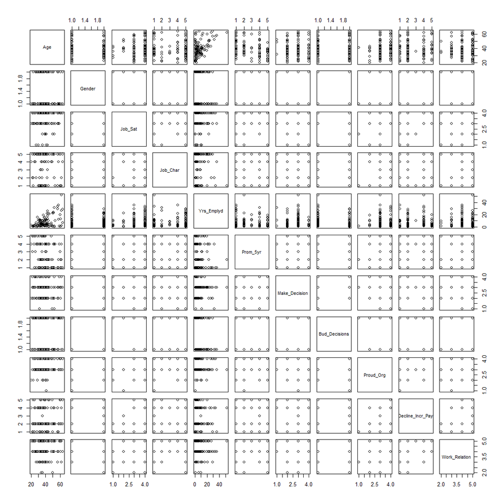

```r
# Plot of all columns

pairs(~ Age + Gender + Job_Sat + Job_Char + Yrs_Emplyd + Prom_5yr + Make_Decision +
        Bud_Decisions + Proud_Org + Decline_Incr_Pay + Work_Relation, data = survey_data)
```

### Observations:

- There appears to be a relationship between Age and Years Employed.
- All other factor variables show some interaction with numeric variables, and need to be further explored. It may be possible that age and yrs employed can have an impact on how employees respond to the survey.
- Some possible relationships between factor variables can be observed where there is no clear grid pattern. For example Job Satisfaction vs. Willingness to decline a higher paying job and other need to be explored.

### Boxplot of Numeric Variables

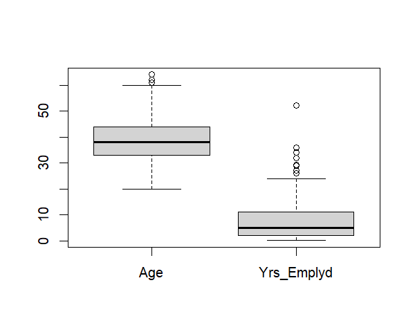

```r
bplot <- boxplot(survey_data[,c(1,5)])
```

### Observations

- Employees surveyed have an age range of 20 to 64 years, with median age of 38.
- About 50% of the employees fall within an age range of 33 to 44, with some outliers greater than 60 years old.
- Most employees have been employed with the company approx. less than 11 years.
- There are several potential outliers who have been employed with the company for more than 20 years.

### Plot QQ Plots for Numeric Values

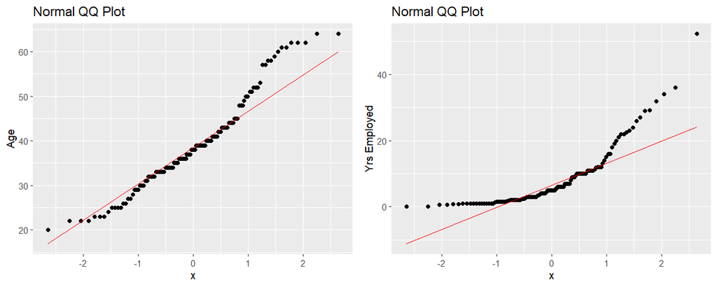

```r
age_qq <- ggplot(survey_data) +
                aes(sample = Age) +
                geom_qq() +
                geom_qq_line(color = "Red") +
                labs(title = "Normal QQ Plot", y = "Age")


yrs_qq <- ggplot(survey_data) +
                aes(sample = Yrs_Emplyd) +
                geom_qq() +
                geom_qq_line(color = "Red") +
                labs(title = "Normal QQ Plot", y = "Yrs Employed")

grid.arrange(age_qq,yrs_qq, ncol=2)
```

### Observations

- Age has a somewhat normal distribution but is impacted by some higher than expected ages above 50.
- Years employed does not seem to follow a normal distribution and is impacted by extreme values at the tails.

### Histograms & Density for Numeric Values

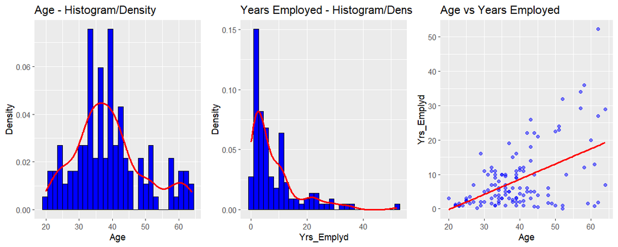

```r
# Histograms & Density

h_plot1<- ggplot(survey_data, aes(x = Age)) +
                geom_histogram(aes(y = ..density.., binwidth = 10), color = "Black", fill = "blue") +
                geom_density(lwd = 1, colour = "Red" ) +
                labs(title = "Age - Histogram/Density", y = "Density")
h_plot2 <- ggplot(survey_data, aes(x = Yrs_Emplyd)) +
                geom_histogram(aes(y = ..density.., binwidth = 10), color = "Black", fill = "blue") +
                geom_density(lwd = 1, colour = "Red" ) +
                labs(title = "Years Employed - Histogram/Density", y = "Density")
age_sex <-ggplot(survey_data, aes(x=Age, y=Yrs_Emplyd))+
                    geom_point(alpha=I(1/2), color = "Blue") +
                    geom_smooth(method = "lm", color = "Red", formula = y~x, se = FALSE)+
                    labs(title = "Age vs Years Employed")


grid.arrange(h_plot1,h_plot2,age_sex, ncol=3)
```

### Observations

- Age has a slight right skew showing the company may have higher than average number of employees who are 50 or older.
- Years employed is showing clear right skew, which is reasonable since few people stay with a company for more than 10 years.
- Years employed shows many of the employees have less than 5 years with the company, which could signal that the company does not provide motivation or opportunities for the employees to stay with the company.
- Scatter plot shows a positive relationship between age and yrs employed, however the dispersion of the points increases when both variables increase, meaning there is a high number of employees greater than 50 who have been with the company just a few years and many years.

### Plot Gender Data

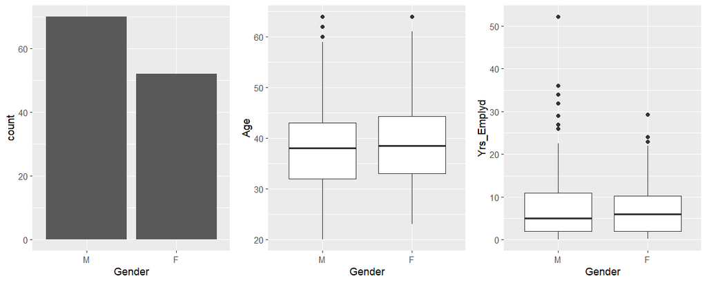

```r
gen1 <- ggplot(survey_data, aes(x=Gender)) + geom_bar()

gen2 <- ggplot(survey_data,aes(x=Gender, y=Age)) + geom_boxplot()

gen3 <- ggplot(survey_data,aes(x=Gender, y=Yrs_Emplyd)) + geom_boxplot()

grid.arrange(gen1, gen2, gen3, ncol=3)
```

### Observations

- Company has more male than females but median age for both groups is similar near 38.
- Most of the female employees are slightly older than males, but there are more males who are greater than 60.
- There is a higher number of males who have been employed with the company for more than 20 yrs.

### Plot Job Satisfcation

```r
# Job Satisfaction Pie Chart

js <- survey_data$Job_Sat

js_tot <- length(js)

js_count <- data.frame(table(survey_data$Job_Sat))

js_count$percent <- js_count$Freq/js_tot

js_count$labels <- percent(js_count$percent)

js_count
```

| Var1 | Freq | percent | labels |
| --- | --- | --- | --- |
| VDis_Sat | 7 | 0.05737705 | 5.74% |
| ModDis_Sat | 6 | 0.04918033 | 4.92% |
| Mod_Sat | 44 | 0.36065574 | 36.07% |
| V_Sat | 65 | 0.53278689 | 53.28% |

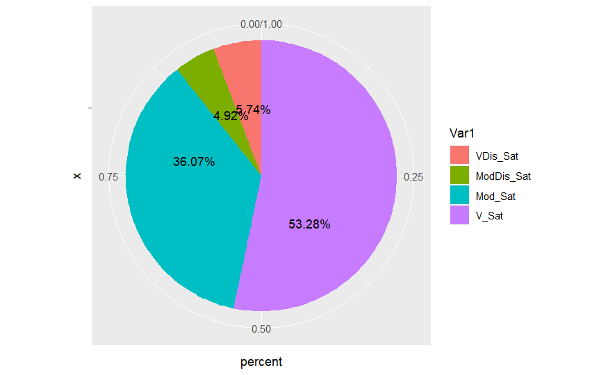

```r
splot1 <- ggplot(js_count, aes(x = "", y = percent, fill = Var1)) +
                  geom_col() +
                  geom_text(aes(label = labels),
                  position = position_stack(vjust = 0.7)) +
                  coord_polar(theta = "y")

splot1
```

### Obseravations

- Approx. 905 of the employees are satisfied and more than 50% are very satisfied, which is good for retaining and attracting talent.
- However, it would be important to see why so many employees don’t stay with the company even though they are satisfied.

### Plot Job Satisfaction vs Gender & Yrs Employed

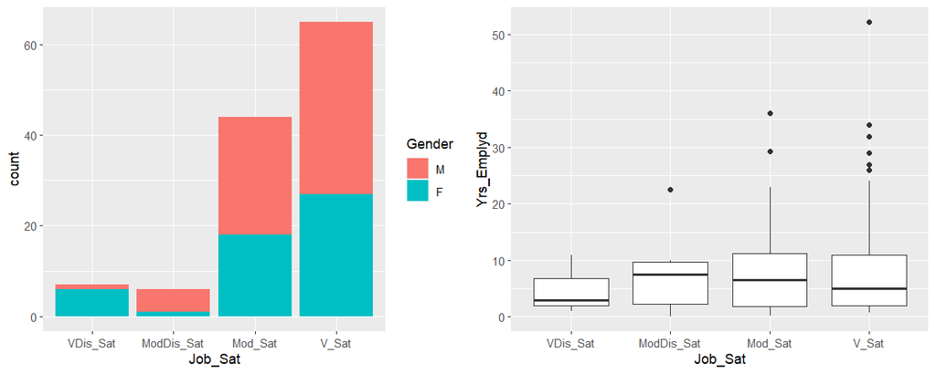

```r
# Job Satisfaction by Gender

splot2 <- ggplot(survey_data, aes(x=Job_Sat, fill = Gender)) + geom_bar()

# Job Satisfaction vs Yrs Employed

splot3 <- ggplot(survey_data, aes(y=Yrs_Emplyd, x=Job_Sat)) + geom_boxplot()

grid.arrange(splot2, splot3, ncol=2)
```

### Plots for Important Job Characteristics

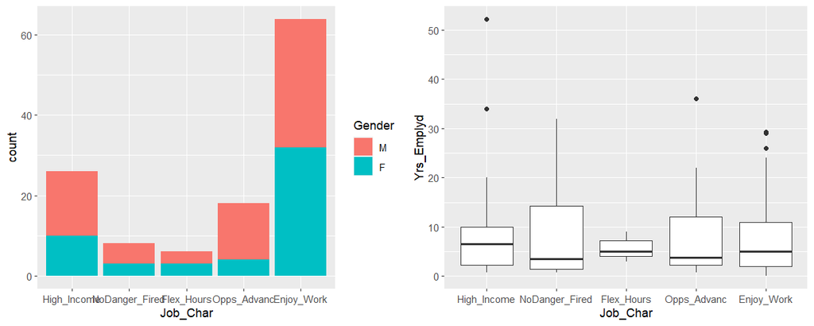

```r
char1 <- ggplot(survey_data, aes(x=Job_Char, fill = Gender)) + geom_bar()

char2 <- ggplot(survey_data,aes(x=Job_Char, y=Yrs_Emplyd)) + geom_boxplot()

grid.arrange(char1, char2, ncol=2)
```

### Likely To Be Promoted in 5 years

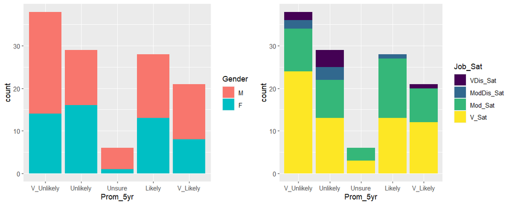

```r
prom1 <- ggplot(survey_data, aes(x=Prom_5yr, fill = Gender)) + geom_bar()

prom2 <- ggplot(survey_data,aes(x=Prom_5yr, fill = Job_Sat)) + geom_bar()

grid.arrange(prom1, prom2, ncol=2)
```

### Observations

- Most employees are unsure or believe it is unlikely that they will be promoted in the next five years, which combined with the desire to earn higher income could lead them to not remain with the company.
- Interestingly employees who do not believe they won’t receive a promotion are satisfied with their job, so its important to determine what factors may drive them to leave the company.

### Plot Ability to Make Decisions

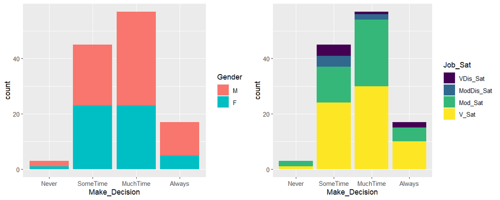

```r
mak1 <- ggplot(survey_data, aes(x=Make_Decision, fill = Gender)) + geom_bar()

mak2 <- ggplot(survey_data,aes(x=Make_Decision, fill = Job_Sat)) + geom_bar()

grid.arrange(mak1, mak2, ncol=2)
```

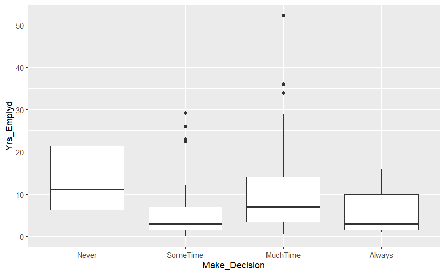

```r
mak3 <- ggplot(survey_data,aes(x=Make_Decision, y=Yrs_Emplyd)) + geom_boxplot()
mak3
```

### Observations

- Most employees have the ability to make decision much of the time or always. Most of these employees are satisfied with their job.
- Making decisions may not be important since most employees who do not have this ability are also satisfied.
- Making decision may impact length of employment since employees who do not make decision appear to have worked for the company for longer.

### Plot Budget Decisions

[figure not shown]

```r
bud1 <- ggplot(survey_data, aes(x=Bud_Decisions, fill = Gender)) + geom_bar()

bud2 <- ggplot(survey_data,aes(x=Job_Sat, fill = Bud_Decisions)) + geom_bar()

grid.arrange(prom1, prom2, ncol=2)
```

### Plot Proud of Organization

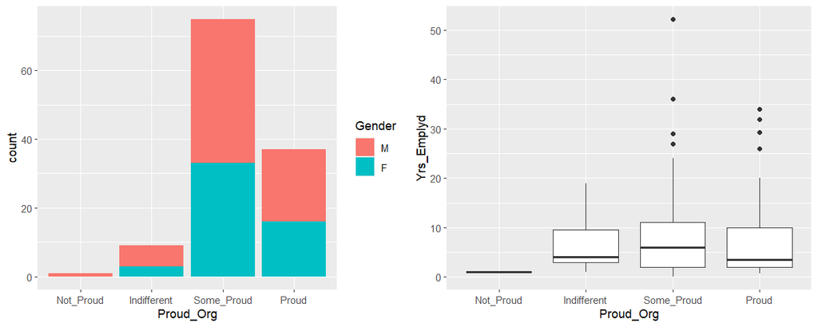

```r
prd1 <- ggplot(survey_data, aes(x=Proud_Org, fill = Gender)) + geom_bar()

prd2 <- ggplot(survey_data,aes(x=Proud_Org, y=Yrs_Emplyd)) + geom_boxplot()

grid.arrange(prd1, prd2, ncol=2)
```

### Plot Turn Down A Higher Paying Job

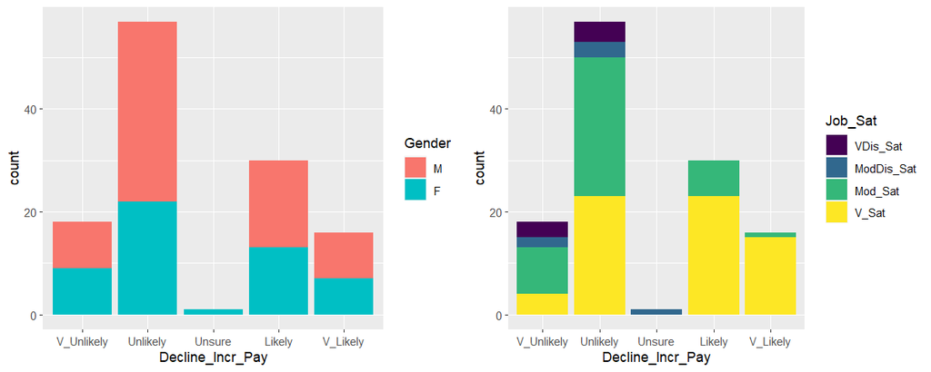

```r
dec1 <- ggplot(survey_data, aes(x=Decline_Incr_Pay, fill = Gender)) + geom_bar()

dec2 <- ggplot(survey_data, aes(x=Decline_Incr_Pay, fill = Job_Sat)) + geom_bar()

grid.arrange(dec1, dec2, ncol=2)
```

### Plot Workplace Relationship Ratings

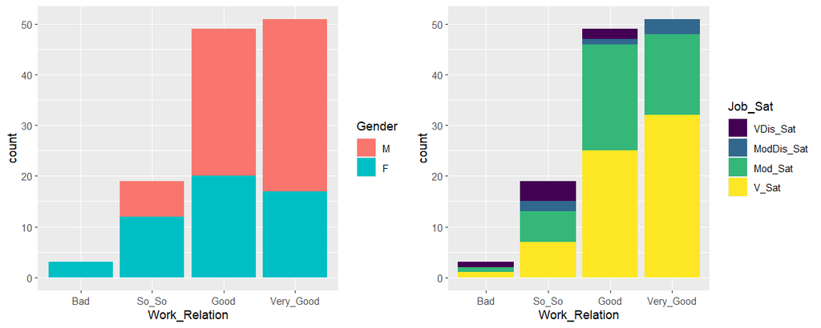

```r
rel1 <- ggplot(survey_data, aes(x=Work_Relation, fill = Gender)) + geom_bar()

rel2 <- ggplot(survey_data, aes(x=Work_Relation, fill = Job_Sat)) + geom_bar()

grid.arrange(rel1, rel2, ncol=2)
```

### Observations

- Most employees appear to have good working relationships.
- The graphs also show that having good relationships can lead to higher job satisfaction.